# Homework 2- Statistical Thinking

Arjun Kumar

2024-01-29

## **Question 1**

**Part A**

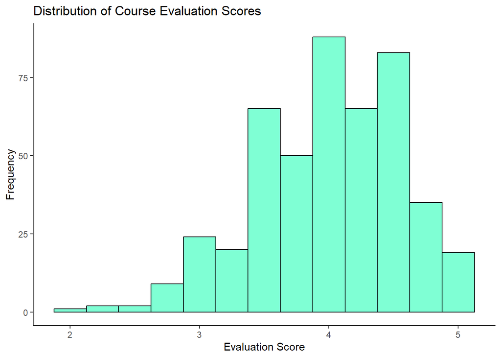

*Median: 4 | Mean: 3.998*

This histogram depicts a heavy left skew, demonstrating how most of the evaluation ratings are more lenient towards the 4-5 region in comparison to the low ratings of around 2-3. This is apparent through the median rating, as well as the mode being concentrated at 4, while the mean is 3.998, being very close to the median value as well. This demonstrates how the school has an overall high evaluation rating of the professors, correlating to a high degree of satisfaction with the education the students are receiving.

**Part B**

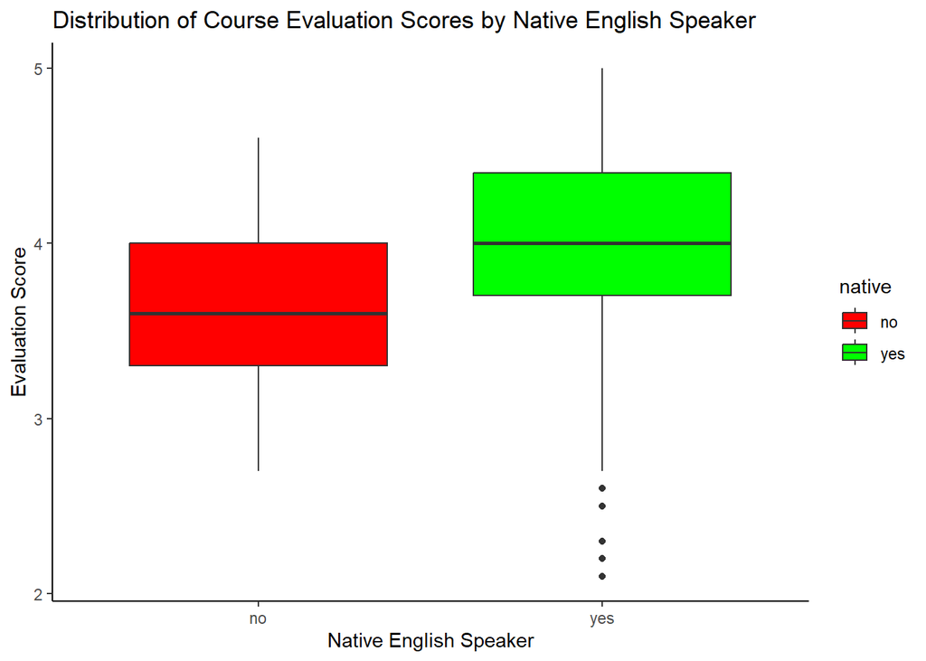

Mean Evaluation Scores by Native English Speaker

| native | eval |
| --- | --- |
| no | 3.689286 |
| yes | 4.018161 |

Although there is not a significant difference, it is apparent that the professors who’s native language is English have higher evaluation ratings overall compared to those who’s native language is not English. This is seen through the overall distribution of the non-native speaker’s having a lower Q1, median and Q3 as well as maximum value being lower as well. However, the native speakers do have multiple outliers, including the lowest rating value of the dataset. However, the mean evaluation of the native speakers comes out to 4.02, while the non-native speakers was 3.69, demonstrating a sizeable difference between the two.

**Part C**

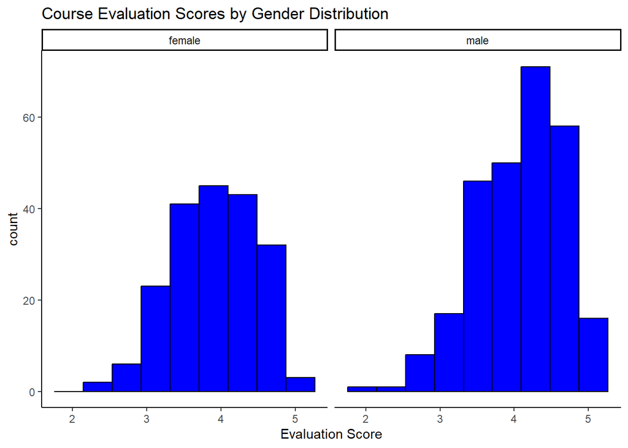

Mean Evaluation Scores by Gender

| gender | eval |
| --- | --- |
| female | 3.901026 |
| male | 4.069030 |

**Part D**

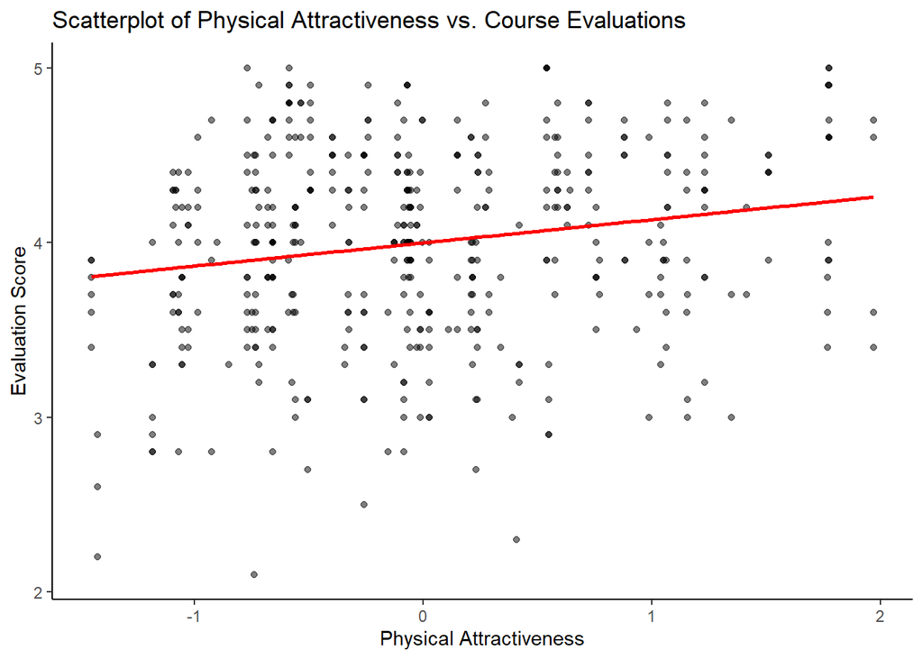

*Correlation Coefficient: 0.1890391*

Looking at the scatterplot and the line of best fit, there is a very slight, positive correlation, nearing no correlation whatsoever. This leads me to believe the attractiveness of the professor has no significant impact on the evaluation they receive. The correlation coefficient is also around 0.18, further proving this point.

## **Question 2**

**Data Wrangling**

**Part A**

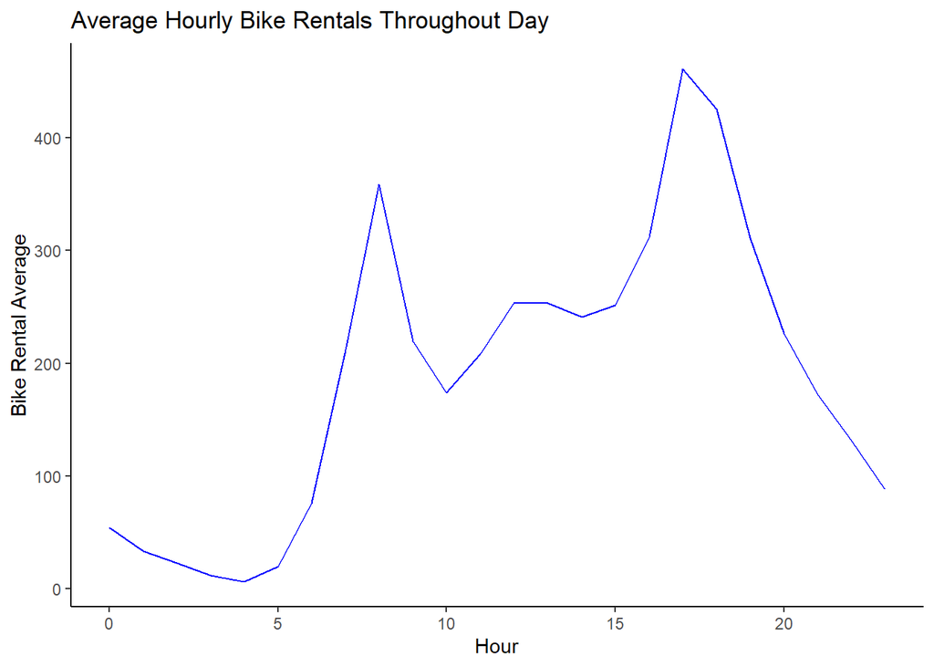

**Part B**

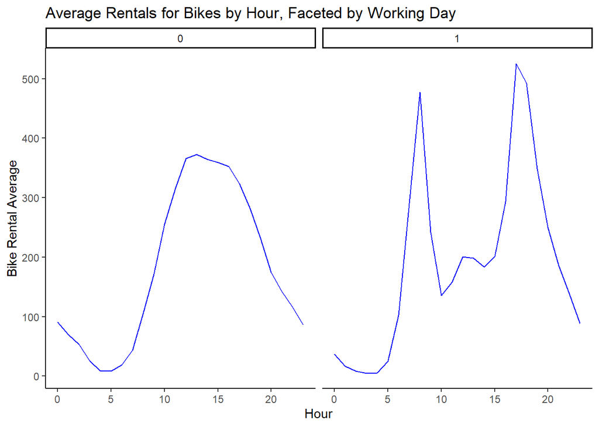

On a non-working day(0), the hourly rental average sees a basic trend, going up from hours 5 to approximately 12.5 hours. Then it steadily goes down until hour 24. For a working day(1), The rentals steeply incline until around hour 8, the steeply declines until 10. It then goes steadily up slowly until hour 15, then exponentially upwards till hour 18, then steeply drops off until 24. The schedule for a workday is much more erratic on a workday, potentially due to the work schedule of many people, and the more relaxed schedule of a non-work day. This faceted line graph illustrates the average bike rentals by hour of the day, faceted by whether it is a working day or not. The x-axis shows the hour of the day, and the y-axis represents the average number of bike rentals. The blue lines depict the trend of bike rentals for each category of working day.

**Part C**

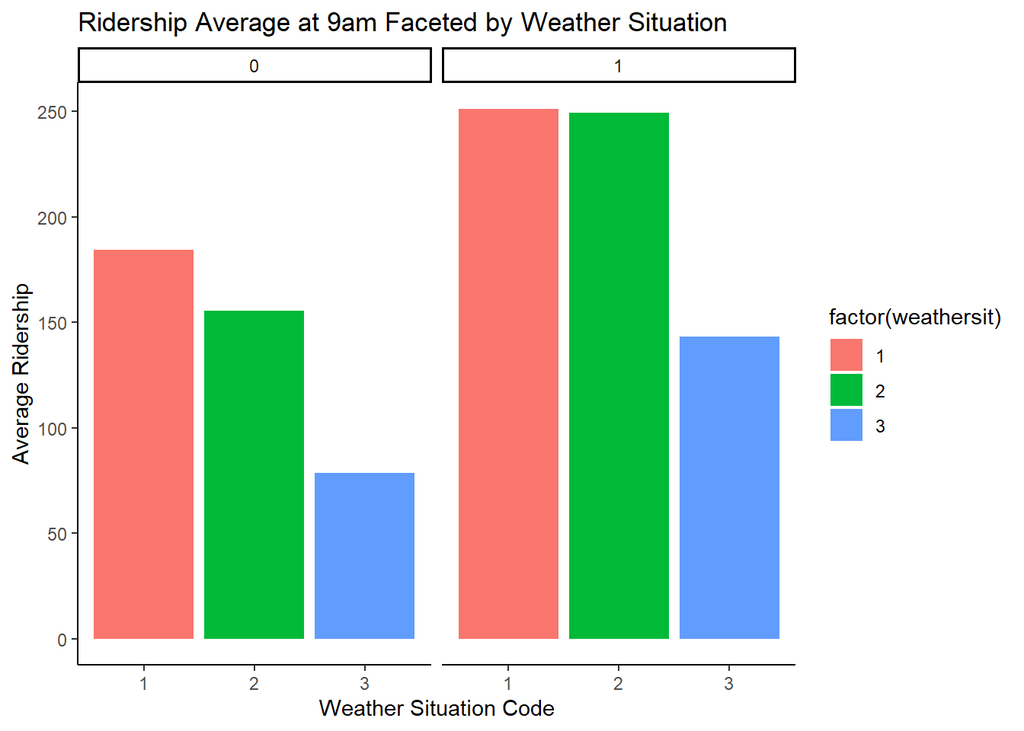

The weather situations, in which 1 represents: Clear, Few clouds, Partly cloudy, Partly cloudy 2 represents: Mist + Cloudy, Mist + Broken clouds, Mist + Few clouds, Mist 3 represents:Light Snow, Light Rain + Thunderstorm + Scattered clouds, Light Rain + Scattered clouds 4: Heavy Rain + Ice Pallets + Thunderstorm + Mist, Snow + Fog (Not in Graphs) On weekends, the more favorable the weather conditions, the more ridership was taken seen in the graph with 0. However, on workdays, weather situations 1 and 2 saw almost the same ridership at 9am, but declines off at weather condition 3. This could be due to the fact that these forms of transportation can be necessary for some people to get to work as compared on the weekend.The average ridership during the 9 AM hour is shown in this faceted bar plot by weather scenario code, which is further broken down by whether or not it is a working day. The average ridership is represented by the y-axis, while the weather status code is displayed on the x-axis. The weather status code is reflected in the color of the bars. A working day (1) or a non-working day (0) is represented by each facet. This map sheds light on how working days and the weather impact ridership patterns during morning rush hour.

## **Question 3**

**Re-order variables and Data Wrangling**

**Part A**

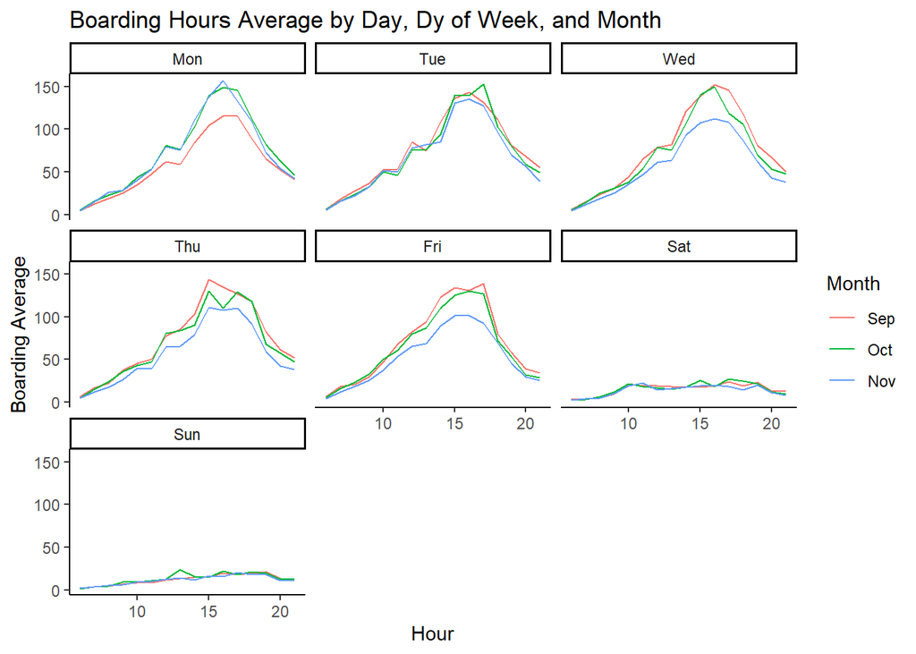

Regardless of the month, Saturday and Sunday are consistently the least active regarding boardings. All of the weekdays have a very similar trend in which they increase highly, but steadily until evening hours(around 15) then see a steep decline. One thing that I also picked up on is that October consistently seemed to be one of the busiest months regardless of the day of the week. This could be due to factors such as work being the busiest during this month, or other lurking variables. The average number of boardings for the UT bus network in Austin is shown in this faceted line graph by hour of the day, day of the week, and month. Every facet symbolizes a weekday, while the lines signify distinct months (September, October, November). The hour of the day is shown by the x-axis, while the average number of boardings is represented by the y-axis. The graphic sheds light on how ridership patterns vary throughout the course of the week and the months.

**Part B**

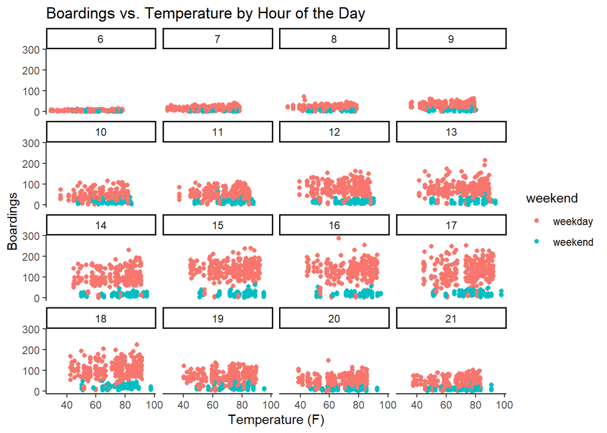

The association between boardings and temperature for the UT bus network in Austin is displayed in this faceted scatter plot each hour of the day. Depending on whether it is a weekday or a weekend, the data points are colored differently. An hour of the day is represented by each facet. The temperature in degrees Fahrenheit is represented by the x-axis, while the number of boardings is represented by the y-axis. We can study how ridership patterns are impacted by temperature throughout the day, taking into account travel on both weekdays and weekends, thanks to this figure. Although the distribution of temperatures is nearly the same whether it is a weekend or weekday, the amount of boardings during the weekdays is consistently much higher than the amount on the weekends.

## **Question 4**

**Part A**

10 Most Popular Songs since 1958 Based on Weeks Spent on The Billboard 100

| performer | song | count |
| --- | --- | --- |
| Imagine Dragons | Radioactive | 87 |
| AWOLNATION | Sail | 79 |
| Jason Mraz | I’m Yours | 76 |
| The Weeknd | Blinding Lights | 76 |
| LeAnn Rimes | How Do I Live | 69 |
| LMFAO Featuring Lauren Bennett & GoonRock | Party Rock Anthem | 68 |
| OneRepublic | Counting Stars | 68 |
| Adele | Rolling In The Deep | 65 |
| Jewel | Foolish Games/You Were Meant For Me | 65 |
| Carrie Underwood | Before He Cheats | 64 |

This table displays the top 10 songs based on the number of weeks each song appeared on the Billboard Top 100 chart.

**Part B**

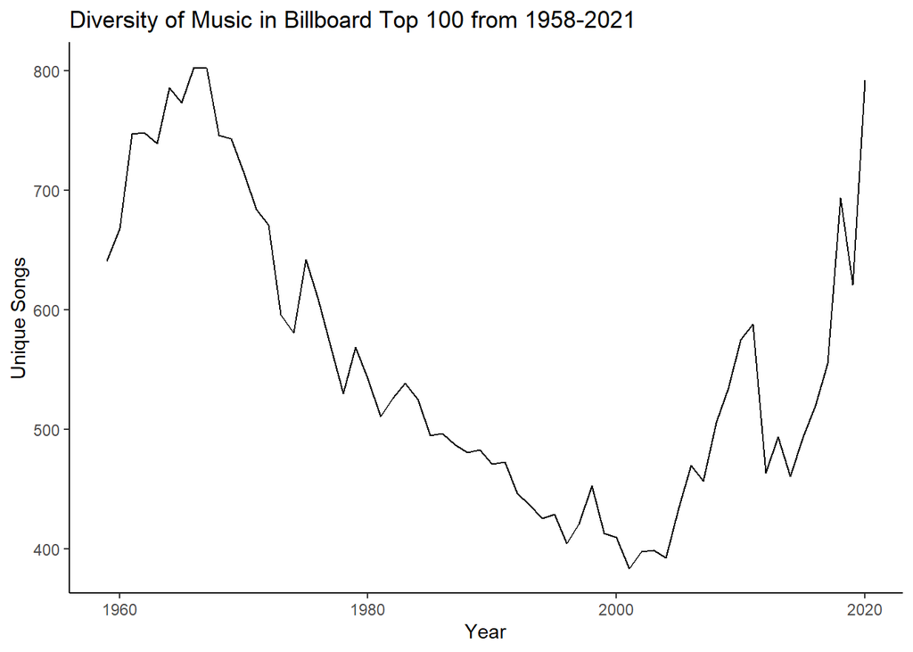

The musical variety of the Billboard Top 100 chart over time is depicted in this line graph. The number of unique songs that appear at each position on the Billboard Top 100 list in any week for each year is displayed on the y-axis, while the x-axis indicates the years. Most notably, the graph shows patterns in the range of songs included on the list, offering insights into how the music industry has changed over time. The amount of unique songs was very high during the last 1960s to early 1970s, then drastically declines to its lowest point in 2000. It then began to pick back up to near its peak of 800 in 2020.

**Part c**

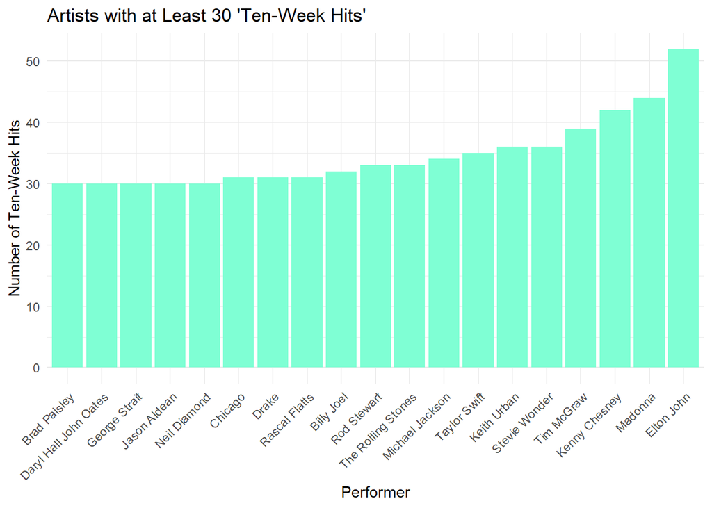